# Project Stage 2, Summary Report

Nick Andriese

2022-08-02

# 1 Part A

## 1.1 Import Data and Change Column Names

```r
library(readr)
library(tidyverse)
hdata <- read_csv("hmda_sw.csv")
colnames(hdata) <- (c("SEQ", "LoanType", "LoanPurpose", "Occupancy","LoanAmmount", "TypeAction", "MSAloc", "CountyLoc", "RaceAppl","RaceCoApp", "SexApp", "SexCoApp", "ApplIncome", "PurchType","HMDAorig", "Correction1", "Correction2", "Correction3", "UnitsProp","MaritalSt", "DepApp", "YearsAppLW", "YearsAppJob", "SelfEmpApp","BaseMIncomeApp", "BaseMIncomeCoApp", "TotalMIncomeApp", "TotalMIncomeCoApp", "ProposedMHouseExp", "PurchasePrice", "OtherFinancing", "LiquidAssets", "CommercialCredit", "AppHistoryGood", "CreditLines", "CH_mortgage", "CH_consumer", "CH_public", "Debt/IncomeHousing", "Debt/IncomeTotal", "F_or_A_loan", "TermLoan", "SpecialLoanApp", "AppraisedValue", "TypeProperty", "PMIsought", "PMIdenied", "GrantDP", "CoSign", "UnverInfo", "Reviewed", "netw", "uria", "rtdum", "bd", "mi", "old", "vr", "school", "chvalc", "dnotown", "dprop"))
```

## 1.2 Data Cleaning, Selection, and Factor Labeling

### 1.2.1 Data Cleaning

```r
### Clean errors/missing observations ###

hdata[hdata == 999999.4] <- NA
hdata[hdata == 999999] <- NA
```

### 1.2.2 Variable Selection

- Outcome/Dependent Variable: “TypeAction”
- Variables required by Professor Eubanks: “Debt/IncomeTotal”, “RaceAppl”, “MaritalSt”, “SelfEmpApp”, “school”

The following variables were selected because Munnell et al. 1996, remark that all economic factors that are both correlated with race and origination decisions must be accounted for in the model. Additionally, they state that loan, property and applicant personal characteristics should all be included as they are also taken into when determining the risks and costs of a loan.

Loan information variables:

Applicant finances, employment, and income variables:

- “YearsAppLW”, “YearsAppJob”, “netw”, “AppHistoryGood”, “CH_mortgage”, “CH_consumer”, “CH_public”, “LiquidAssets”, “TotalMoIncomeApp”, “TotalMIncomeCoApp”, “OtherFinancing”, “GrantDP”, “CoSign”, “uria”, “Debt/IncomeHousing”

Applicant personal information variables:

- “RaceCoApp”, “SexApp”, “SexCoApp”, “DepApp”, “old”

Property Location information variables:

- “CountyLoc”, “rtdum”, “bd”, “mi”, “vr”, “chvalc”

*Unincluded Variables:

- “LoanType” - only one type; “Loan Purpose” - only one purpose; “MSAloc” - only one MSA location (1120); “HMDAorig” - these are outcomes that are dependent on our selected independent and shouldn’t explain racial bias more than our selected variables; “Correction1”, “Correction2”, “Correction3” - all not necessary as they are corrections of reason for denial; “ApplIncome”, “BaseMontlyIncomeApp”, “BaseMonthlyIncomeCoApp” - to help reduce colinearity with the other more precise income measures; “Occupancy” - is dummycoded under “dnotown”; “TypeProperty” is dummycoded under “dprop”; “SpecialLoanApp” is a character variable with many different types that would be hard to initerpret and not helpful in the analysis; “dprop” only has one type - single family homes/condominiums.

### 1.2.3 Hypotheses (Professor Eubank’s Variables)

H1 “Debt/Income Total” will be negatively related to probability of being approved, where the greater the debt, the less likelihood of being approved.

H2 “MaritallSt”: after controlling for relevant variables, being married will have a weak and positive relationship with the likelihood of being approved. Being married may increase the likelihood of more income in the household.

H3 “SelfEmpApp”: after controlling for relevant variables, being self employed will decrease the likelihood of being approved. Being self employed does not consitute a constant stream of income and introduces more uncertainty.

H4 “school”: after controlling for relevant variables, years of education will be positively related with the likelihood of being approved. Levels of education are positively related to income, which increases the likelihood of being approved.

H5 “RaceAppl”: after controlling for relevant variables, being Black will have a very weak and negative relationship with the likelihood of being approved due to potential racial bias.

```r
hd <- hdata[ ,c("TypeAction", "Debt/IncomeTotal", "RaceAppl", "MaritalSt", "SelfEmpApp", "school", "LoanAmmount", "PurchType",  "PurchasePrice", "TermLoan", "F_or_A_loan",  "AppraisedValue", "PMIsought", "PMIdenied", "UnverInfo", "Reviewed", "dnotown", "YearsAppLW", "YearsAppJob", "netw", "Debt/IncomeHousing", "AppHistoryGood", "CH_mortgage", "CH_consumer",  "CH_public", "LiquidAssets", "TotalMIncomeApp", "TotalMIncomeCoApp", "OtherFinancing", "GrantDP", "CoSign", "uria",  "RaceCoApp", "SexApp", "SexCoApp", "DepApp", "old", "CountyLoc", "rtdum", "bd", "mi", "vr", "chvalc" )]
```

### 1.2.4 Factor Creation and Level Labeling

```r
# Converting TypeAction to dummy variables of 0 (Denied and 1 (Approved)
hd$TypeAction[hd$TypeAction == 2] <- 1
hd$TypeAction[hd$TypeAction == 3] <- 0
hd$TypeAction <- as.factor(hd$TypeAction)
levels(hd$TypeAction) <- c("Loan Denied", "Loan Approved")

hd$CountyLoc <- as.factor(hd$CountyLoc)
levels(hd$CountyLoc) <- c("Suffolk", "other")

hd$RaceAppl<- as.factor(hd$RaceAppl)
levels(hd$RaceAppl) <- c("Black", "White")


table(hd$RaceCoApp)
```

```
##
##    1    2    3    4    5    6    7    8
##    7   11  178    5 1463    4   43  668
```

```r
hd$RaceCoApp[hd$RaceCoApp == 7] <- NA
hd$RaceCoApp<- as.factor(hd$RaceCoApp)
levels(hd$RaceCoApp) <- c("American Indian or Alaskan native", "Asian or Pacific Islander", "Black", "Hispanic", "White", "Other", "Not Applicable")

table(hd$SexApp)
```

```
##
##    1    2    3
## 1867  495   18
```

```r
hd$SexApp[hd$SexApp==3] <- NA
hd$SexApp<- as.factor(hd$SexApp)
levels(hd$SexApp) <- c("Male", "Female")

hd$SexCoApp[hd$SexCoApp==8] <- NA #invalid level of 8 needed to be removed
hd$SexCoApp[hd$SexCoApp==3] <- NA
hd$SexCoApp[hd$SexCoApp==4] <- NA
table(hd$SexCoApp)
```

```
##
##    1    2
##  173 1481
```

```r
hd$SexCoApp <- as.factor(hd$SexCoApp)
levels(hd$SexCoApp) <- c("Male", "Female")


hd$PurchType[hd$PurchType == 2 ] <- NA #moved to NA because causes issues in the cross validation (changes # of levels between groups)
hd$PurchType <- as.factor(hd$PurchType)
levels(hd$PurchType) <- c("Loan was not sold in calendar year covered by register", "FNMA", "FHLMC", "FMHA", "Commercial Bank", "Savings bank or savings association", "Life Insurance company", "Affiliate instituion")


hd$MaritalSt[hd$MaritalSt == "S"] <- "U"
hd$MaritalSt <- as.factor(hd$MaritalSt)
levels(hd$MaritalSt) <-  c("Married", "Unmarried (separated, single, divorced, or widowed)")

hd$SelfEmpApp <- as.factor(hd$SelfEmpApp)
levels(hd$SelfEmpApp) <- c("Not Self-employed", "Self-employed")

hd$AppHistoryGood[hd$AppHistoryGood==666] <- NA #cleaned value
hd$AppHistoryGood <- as.factor(hd$AppHistoryGood)
levels(hd$AppHistoryGood) <- c("No", "Yes")

hd$CH_mortgage <- as.factor(hd$CH_mortgage)
levels(hd$CH_mortgage) <-c("Not late mortgage payments", "No mortgage payment history", "ONe or two late mortgage payments", "More than two late mortgage payments")

hd$CH_consumer <- as.factor(hd$CH_consumer)
levels(hd$CH_consumer) <- c("no slow pay or delinquent accounts, but sufficient references for determination", "One or two slow pay accounts each with one or two payments 30 days past due", "More than two slow pay accounts each with one or two payments 30 days past due; or one or two chronic slow pay accounts with three or more payments 30 days paste due in any 12-month period", "insufficient credit history or references for determination", "delinquent credit history containing accounts with a history of payments 60 days past due", "Serious delinquencies containing accounts with a history of payments 90 days past due") #should I shorten these?*****

hd$CH_public <- as.factor(hd$CH_public)
levels(hd$CH_public) <- c("Info not included or no public record defaults", "Bankruptcy or defaults") #there are multiple 0 and 1's with different labels - can't change now because we don't know which 0's and 1's are which, therefore all 0's will be 0 and all 1's will be 1.

hd$F_or_A_loan[hd$F_or_A_loan == 3] <- NA
hd$F_or_A_loan <- as.factor(hd$F_or_A_loan)
levels(hd$F_or_A_loan) <- c("Adjustable", "Fixed")

hd$PMIsought <- as.factor(hd$PMIsought)
levels(hd$PMIsought) <- c("No or info not available", "Yes")

hd$PMIdenied <- as.factor(hd$PMIdenied)
levels(hd$PMIdenied)  <- c("PMI approve, did not apply, or info not available", "PMI sought and DENIED")

hd$GrantDP <- as.factor(hd$GrantDP)
levels(hd$GrantDP) <- c("No or not available", "Yes")

hd$CoSign <- as.factor(hd$CoSign)
levels(hd$CoSign) <- c("No or not available", "Yes")

hd$UnverInfo <- as.factor(hd$UnverInfo)
levels(hd$UnverInfo) <- c("Not applicable (all verifiable)", "Some information unverifiable")

hd$rtdum <- as.factor(hd$rtdum)
levels(hd$rtdum) <- c("≤ .30", "> .30")

hd$bd <- as.factor(hd$bd)
levels(hd$bd) <- c("≤ MSA median", "> MSA median")

hd$mi <- as.factor(hd$mi)
levels(hd$mi) <- c("≤ MSA median", "> MSA median")

hd$old[hd$old==2] <- NA #remove "missing" factor
hd$old <- as.factor(hd$old)
levels(hd$old) <- c("≤ MSA median", "> MSA median")

hd$vr <- as.factor(hd$vr)
levels(hd$vr) <- c("≤ MSA median", "> MSA median")

hd$dnotown <- as.factor(hd$dnotown)
levels(hd$dnotown) <- c("Owner Occupied", "Not owner occupied, or information not available")
```

# 2 Part B

## 2.1 Summary Statistics

```r
library(skimr)
library(gtsummary)
library(gapminder)
library(vtable)
library(psych)
library(summarytools)


print(dfSummary(hd,
                plain.ascii = FALSE,
          varnumbers = FALSE,
          graph.magnif = 0.75,
          valid.col    = FALSE),
          method = "render")
```

Data Frame Summary

hd

**Dimensions**: 2380 x 43  
**Duplicates**: 1

| **Variable** | **Stats / Values** | **Freqs (% of Valid)** | **Graph** | **Missing** |
| --- | --- | --- | --- | --- |
| TypeAction [factor] | 1. Loan Denied 2. Loan Approved | 285 ( 12.0% ) 2095 ( 88.0% ) |  | 0 (0.0%) |
| Debt/IncomeTotal [numeric] | Mean (sd) : 33.1 (10.7) min ≤ med ≤ max: 0 ≤ 33 ≤ 300 IQR (CV) : 9 (0.3) | 519 distinct values |  | 0 (0.0%) |
| RaceAppl [factor] | 1. Black 2. White | 339 ( 14.2% ) 2041 ( 85.8% ) |  | 0 (0.0%) |
| MaritalSt [factor] | 1. Married 2. Unmarried (separated, sin | 1444 ( 60.7% ) 934 ( 39.3% ) |  | 2 (0.1%) |
| SelfEmpApp [factor] | 1. Not Self-employed 2. Self-employed | 2103 ( 88.4% ) 277 ( 11.6% ) |  | 0 (0.0%) |
| school [numeric] | Mean (sd) : 15.5 (2.9) min ≤ med ≤ max: 5 ≤ 16 ≤ 27 IQR (CV) : 4 (0.2) | 26 distinct values |  | 23 (1.0%) |
| LoanAmmount [numeric] | Mean (sd) : 139.1 (83.4) min ≤ med ≤ max: 2 ≤ 122 ≤ 980 IQR (CV) : 63 (0.6) | 302 distinct values |  | 0 (0.0%) |
| PurchType [factor] | 1. Loan was not sold in cale 2. FNMA 3. FHLMC 4. FMHA 5. Commercial Bank 6. Savings bank or savings a 7. Life Insurance company 8. Affiliate instituion | 1154 ( 51.0% ) 485 ( 21.4% ) 216 ( 9.5% ) 39 ( 1.7% ) 34 ( 1.5% ) 5 ( 0.2% ) 120 ( 5.3% ) 211 ( 9.3% ) |  | 116 (4.9%) |
| PurchasePrice [numeric] | Mean (sd) : 189.9 (130.4) min ≤ med ≤ max: 0 ≤ 155 ≤ 1535 IQR (CV) : 92.6 (0.7) | 495 distinct values |  | 4 (0.2%) |
| TermLoan [numeric] | Mean (sd) : 342.5 (63.2) min ≤ med ≤ max: 6 ≤ 360 ≤ 480 IQR (CV) : 0 (0.2) | 15 distinct values |  | 4 (0.2%) |
| F_or_A_loan [factor] | 1. Adjustable 2. Fixed | 788 ( 33.2% ) 1588 ( 66.8% ) |  | 4 (0.2%) |
| AppraisedValue [numeric] | Mean (sd) : 198.5 (153) min ≤ med ≤ max: 25 ≤ 160 ≤ 4316 IQR (CV) : 94 (0.8) | 447 distinct values |  | 0 (0.0%) |
| PMIsought [factor] | 1. No or info not available 2. Yes | 1843 ( 77.4% ) 537 ( 22.6% ) |  | 0 (0.0%) |
| PMIdenied [factor] | 1. PMI approve, did not appl 2. PMI sought and DENIED | 2332 ( 98.0% ) 48 ( 2.0% ) |  | 0 (0.0%) |
| UnverInfo [factor] | 1. Not applicable (all verif 2. Some information unverifi | 2267 ( 95.3% ) 113 ( 4.7% ) |  | 0 (0.0%) |
| Reviewed [numeric] | Mean (sd) : 1.9 (1.2) min ≤ med ≤ max: 0 ≤ 2 ≤ 15 IQR (CV) : 1 (0.6) | 13 distinct values |  | 243 (10.2%) |
| dnotown [factor] | 1. Owner Occupied 2. Not owner occupied, or in | 2300 ( 96.6% ) 80 ( 3.4% ) |  | 0 (0.0%) |
| YearsAppLW [numeric] | Mean (sd) : 10.6 (7.7) min ≤ med ≤ max: 0 ≤ 9 ≤ 45 IQR (CV) : 10 (0.7) | 93 distinct values |  | 47 (2.0%) |
| YearsAppJob [numeric] | Mean (sd) : 6.5 (6.6) min ≤ med ≤ max: 0 ≤ 4 ≤ 43 IQR (CV) : 7 (1) | 121 distinct values |  | 53 (2.2%) |
| netw [numeric] | Mean (sd) : 253 (1072.6) min ≤ med ≤ max: -7919 ≤ 86 ≤ 28023 IQR (CV) : 179.4 (4.2) | 1179 distinct values |  | 0 (0.0%) |
| Debt/IncomeHousing [numeric] | Mean (sd) : 25.5 (9.7) min ≤ med ≤ max: 0 ≤ 26 ≤ 300 IQR (CV) : 8.5 (0.4) | 500 distinct values |  | 0 (0.0%) |
| AppHistoryGood [factor] | 1. No 2. Yes | 210 ( 8.8% ) 2167 ( 91.2% ) |  | 3 (0.1%) |
| CH_mortgage [factor] | 1. Not late mortgage payment 2. No mortgage payment histo 3. ONe or two late mortgage 4. More than two late mortga | 747 ( 31.4% ) 1571 ( 66.0% ) 41 ( 1.7% ) 21 ( 0.9% ) |  | 0 (0.0%) |
| CH_consumer [factor] | 1. no slow pay or delinquent 2. One or two slow pay accou 3. More than two slow pay ac 4. insufficient credit histo 5. delinquent credit history 6. Serious delinquencies con | 1353 ( 56.8% ) 441 ( 18.5% ) 126 ( 5.3% ) 77 ( 3.2% ) 182 ( 7.6% ) 201 ( 8.4% ) |  | 0 (0.0%) |
| CH_public [factor] | 1. Info not included or no p 2. Bankruptcy or defaults | 2205 ( 92.6% ) 175 ( 7.4% ) |  | 0 (0.0%) |
| LiquidAssets [numeric] | Mean (sd) : 93.1 (315) min ≤ med ≤ max: 0 ≤ 36 ≤ 8650 IQR (CV) : 62 (3.4) | 733 distinct values |  | 12 (0.5%) |
| TotalMIncomeApp [numeric] | Mean (sd) : 4914 (5162.5) min ≤ med ≤ max: 0 ≤ 3597.5 ≤ 81000 IQR (CV) : 2625.8 (1.1) | 1545 distinct values |  | 0 (0.0%) |
| TotalMIncomeCoApp [numeric] | Mean (sd) : 1471.8 (2358.9) min ≤ med ≤ max: 0 ≤ 921.5 ≤ 41667 IQR (CV) : 2305.2 (1.6) | 910 distinct values |  | 0 (0.0%) |
| OtherFinancing [numeric] | Mean (sd) : 4.5 (87.9) min ≤ med ≤ max: 0 ≤ 0 ≤ 3908 IQR (CV) : 0 (19.5) | 71 distinct values |  | 0 (0.0%) |
| GrantDP [factor] | 1. No or not available 2. Yes | 1979 ( 83.2% ) 400 ( 16.8% ) |  | 1 (0.0%) |
| CoSign [factor] | 1. No or not available 2. Yes | 2310 ( 97.1% ) 70 ( 2.9% ) |  | 0 (0.0%) |
| uria [numeric] | Mean (sd) : 3.8 (2) min ≤ med ≤ max: 1.8 ≤ 3.2 ≤ 10.6 IQR (CV) : 0.8 (0.5) | 1.80 : 217 ( 9.1% ) 2.00 : 148 ( 6.2% ) 3.10 : 275 ( 11.6% ) 3.20 : 877 ( 36.8% ) 3.60 : 174 ( 7.3% ) 3.90 : 229 ( 9.6% ) 4.30 : 220 ( 9.2% ) 5.30 : 65 ( 2.7% ) 8.90 : 16 ( 0.7% ) 10.60 : 159 ( 6.7% ) |  | 0 (0.0%) |
| RaceCoApp [factor] | 1. American Indian or Alaska 2. Asian or Pacific Islander 3. Black 4. Hispanic 5. White 6. Other 7. Not Applicable | 7 ( 0.3% ) 11 ( 0.5% ) 178 ( 7.6% ) 5 ( 0.2% ) 1463 ( 62.6% ) 4 ( 0.2% ) 668 ( 28.6% ) |  | 44 (1.8%) |
| SexApp [factor] | 1. Male 2. Female | 1867 ( 79.0% ) 495 ( 21.0% ) |  | 18 (0.8%) |
| SexCoApp [factor] | 1. Male 2. Female | 173 ( 10.5% ) 1481 ( 89.5% ) |  | 726 (30.5%) |
| DepApp [numeric] | Mean (sd) : 0.8 (1.1) min ≤ med ≤ max: 0 ≤ 0 ≤ 8 IQR (CV) : 1 (1.5) | 0 : 1422 ( 59.7% ) 1 : 379 ( 15.9% ) 2 : 381 ( 16.0% ) 3 : 145 ( 6.1% ) 4 : 40 ( 1.7% ) 5 : 7 ( 0.3% ) 6 : 4 ( 0.2% ) 7 : 1 ( 0.0% ) 8 : 1 ( 0.0% ) |  | 0 (0.0%) |
| old [factor] | 1. ≤ MSA median 2. > MSA median | 1286 ( 54.2% ) 1086 ( 45.8% ) |  | 8 (0.3%) |
| CountyLoc [factor] | 1. Suffolk 2. other | 1965 ( 82.6% ) 415 ( 17.4% ) |  | 0 (0.0%) |
| rtdum [factor] | 1. ≤ .30 2. > .30 | 2207 ( 92.7% ) 173 ( 7.3% ) |  | 0 (0.0%) |
| bd [factor] | 1. ≤ MSA median 2. > MSA median | 1321 ( 55.5% ) 1059 ( 44.5% ) |  | 0 (0.0%) |
| mi [factor] | 1. ≤ MSA median 2. > MSA median | 406 ( 17.1% ) 1974 ( 82.9% ) |  | 0 (0.0%) |
| vr [factor] | 1. ≤ MSA median 2. > MSA median | 1341 ( 56.3% ) 1039 ( 43.7% ) |  | 0 (0.0%) |
| chvalc [numeric] | Mean (sd) : 272.3 (129) min ≤ med ≤ max: -8.3 ≤ 236.5 ≤ 1233.3 IQR (CV) : 54.2 (0.5) | 473 distinct values |  | 16 (0.7%) |

Generated by summarytools 1.0.1 ([R](https://www.r-project.org/) version 4.2.1)  
2022-08-04

## 2.2 Correlations and Plots

```r
cor(hd[,unlist(lapply(hd, is.numeric))], use = "complete.obs")
```

```
##                    Debt/IncomeTotal       school LoanAmmount PurchasePrice
## Debt/IncomeTotal        1.000000000 -0.054688055  0.07332066    0.02024405
## school                 -0.054688055  1.000000000  0.30194577    0.30460176
## LoanAmmount             0.073320657  0.301945770  1.00000000    0.85622812
## PurchasePrice           0.020244047  0.304601764  0.85622812    1.00000000
## TermLoan                0.071697039  0.003866975  0.04562973   -0.02407673
## AppraisedValue         -0.009726694  0.276745382  0.71652922    0.80199680
## Reviewed                0.062781095 -0.013979431  0.03786519    0.04412168
## YearsAppLW             -0.061031625 -0.023897054  0.07206026    0.14187525
## YearsAppJob            -0.035217626 -0.092607998  0.00894019    0.05845892
## netw                   -0.066098627  0.095275734  0.21372689    0.28897694
## Debt/IncomeHousing      0.788068276 -0.062980866  0.06872732    0.01288135
## LiquidAssets            0.007644609  0.091270236  0.27789066    0.32221186
## TotalMIncomeApp        -0.141374792  0.259637577  0.59573520    0.64525685
## TotalMIncomeCoApp      -0.123775828  0.102434640  0.20876086    0.15962005
## OtherFinancing          0.003661994 -0.004167672  0.04961055    0.05853805
## uria                    0.037298298 -0.166060215 -0.08216727   -0.07235471
## DepApp                  0.026771512 -0.052222668  0.14747801    0.16649828
## chvalc                  0.036125955 -0.069550166 -0.10911575   -0.12808819
##                         TermLoan AppraisedValue     Reviewed   YearsAppLW
## Debt/IncomeTotal    7.169704e-02   -0.009726694  0.062781095 -0.061031625
## school              3.866975e-03    0.276745382 -0.013979431 -0.023897054
## LoanAmmount         4.562973e-02    0.716529219  0.037865186  0.072060261
## PurchasePrice      -2.407673e-02    0.801996804  0.044121677  0.141875252
## TermLoan            1.000000e+00   -0.026678677 -0.086374180 -0.093499141
## AppraisedValue     -2.667868e-02    1.000000000  0.049470033  0.114635260
## Reviewed           -8.637418e-02    0.049470033  1.000000000  0.002641232
## YearsAppLW         -9.349914e-02    0.114635260  0.002641232  1.000000000
## YearsAppJob        -5.824380e-02    0.051068309  0.046850404  0.633772020
## netw               -1.170318e-02    0.238672075 -0.002564854  0.119194122
## Debt/IncomeHousing  8.541494e-02   -0.010444295  0.062380285 -0.113380477
## LiquidAssets       -5.703659e-02    0.279187397 -0.004852700  0.091549523
## TotalMIncomeApp    -4.470082e-02    0.543154202  0.003837215  0.205657661
## TotalMIncomeCoApp  -2.687921e-02    0.121246616 -0.010751462 -0.052037485
## OtherFinancing      9.649438e-03    0.050591231  0.031418046 -0.018450383
## uria                9.195099e-05   -0.057900207  0.019788421  0.010850246
## DepApp             -4.922937e-02    0.139235246  0.045099629  0.105236617
## chvalc              4.847798e-02   -0.096106804 -0.021387598 -0.073893575
##                     YearsAppJob         netw Debt/IncomeHousing LiquidAssets
## Debt/IncomeTotal   -0.035217626 -0.066098627         0.78806828  0.007644609
```

[output cut: 40 more lines]

```
## PurchasePrice      -7.235471e-02  0.16649828 -0.128088187
## TermLoan            9.195099e-05 -0.04922937  0.048477981
## AppraisedValue     -5.790021e-02  0.13923525 -0.096106804
## Reviewed            1.978842e-02  0.04509963 -0.021387598
## YearsAppLW          1.085025e-02  0.10523662 -0.073893575
## YearsAppJob         1.096190e-03  0.06446665 -0.020804127
## netw               -1.668917e-02  0.05616694 -0.040301835
## Debt/IncomeHousing  4.486566e-02  0.02075194  0.020438529
## LiquidAssets       -4.021655e-02  0.02277950 -0.041186803
## TotalMIncomeApp    -5.884858e-02  0.12888351 -0.065131007
## TotalMIncomeCoApp  -1.496286e-02 -0.05269520 -0.085043476
## OtherFinancing     -6.849433e-03  0.02084896 -0.007107208
## uria                1.000000e+00  0.04162497 -0.056935362
## DepApp              4.162497e-02  1.00000000  0.033043478
## chvalc             -5.693536e-02  0.03304348  1.000000000
```

```r
cor(hd$`Debt/IncomeTotal`,hd$school, use = "complete.obs")
```

```
## [1] -0.04961513
```

```r
cor(hd$TotalMIncomeApp,hd$school, use = "complete.obs")
```

```
## [1] 0.2468986
```

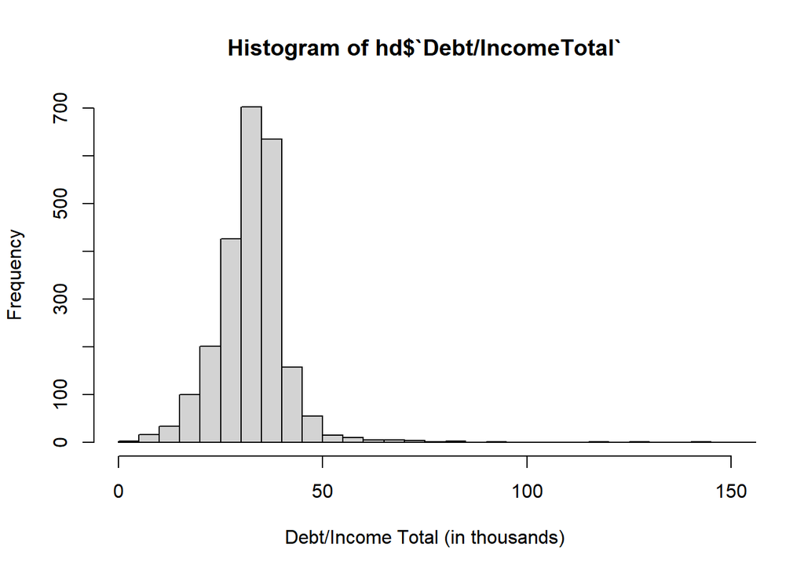

```r
hist(hd$`Debt/IncomeTotal`, xlab = "Debt/Income Total (in thousands)", xlim = c(0,150), breaks = 50)
```

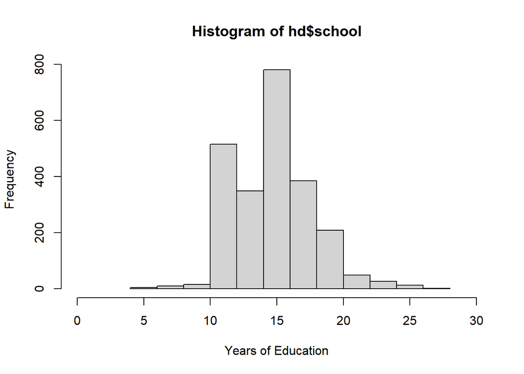

```r
hist(hd$school, xlab = "Years of Education", xlim = c(0,30), breaks = 15)
```

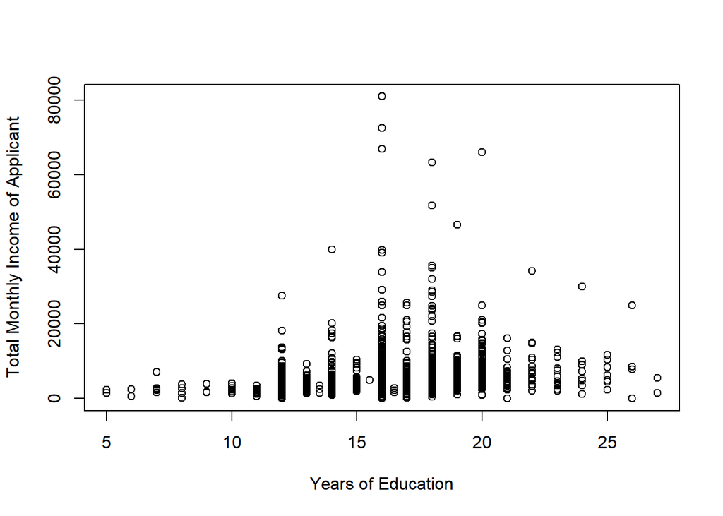

```r
plot(hd$school,hd$TotalMIncomeApp, xlab = "Years of Education", ylab = "Total Monthly Income of Applicant")
```

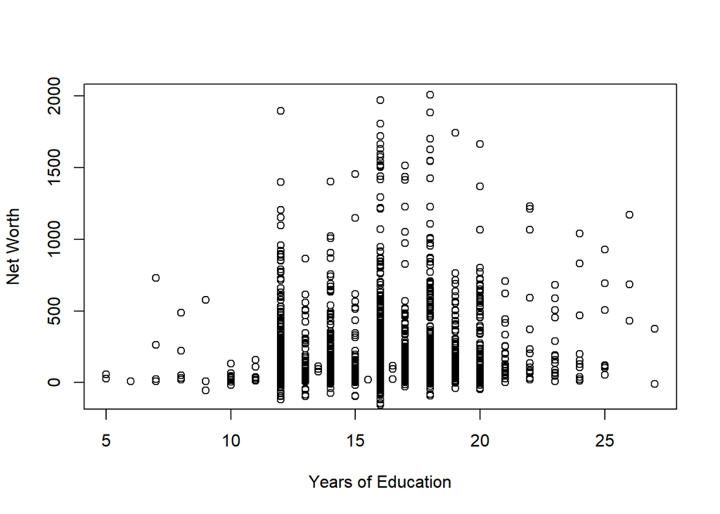

```r
plot(hd$school, hd$netw, ylim = c(-100,2000), xlab = "Years of Education", ylab = "Net Worth")
```

```r
# More plots are in the figure above
```

## 2.3 Transformations

We will be using a square-root transformation for each of these variables, as they are skewed to the right.

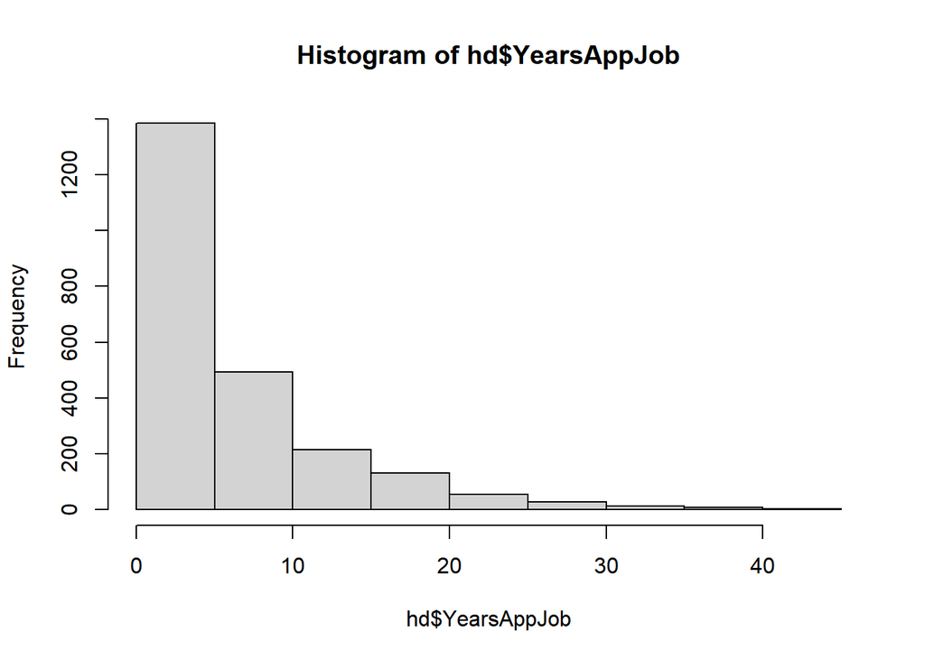

```r
hist(hd$YearsAppJob)
```

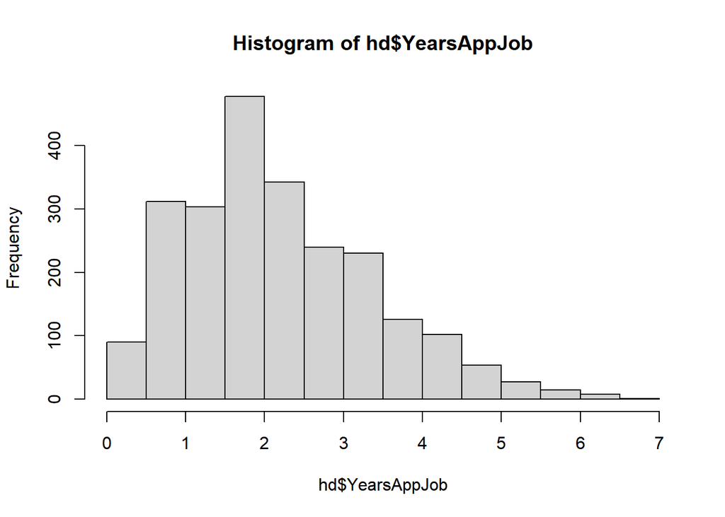

```r
hd$YearsAppJob <- sqrt(hd$YearsAppJob) #skewed right
hist(hd$YearsAppJob, breaks = 20)
```

```r
summary(hd$YearsAppJob)
```

```
##    Min. 1st Qu.  Median    Mean 3rd Qu.    Max.    NA's
##   0.000   1.414   2.000   2.269   3.000   6.557      53
```

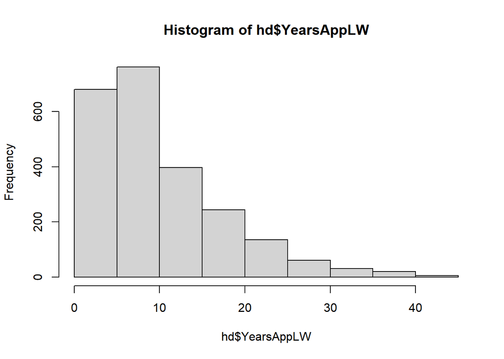

```r
hist(hd$YearsAppLW)
```

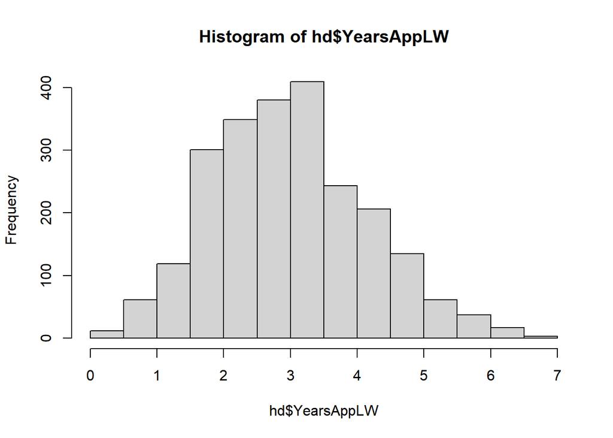

```r
hd$YearsAppLW <- sqrt(hd$YearsAppLW) #skewed right
hist(hd$YearsAppLW, breaks = 20)
```

```r
summary(hd$YearsAppLW)
```

```
##    Min. 1st Qu.  Median    Mean 3rd Qu.    Max.    NA's
##   0.000   2.236   3.000   3.054   3.873   6.708      47
```

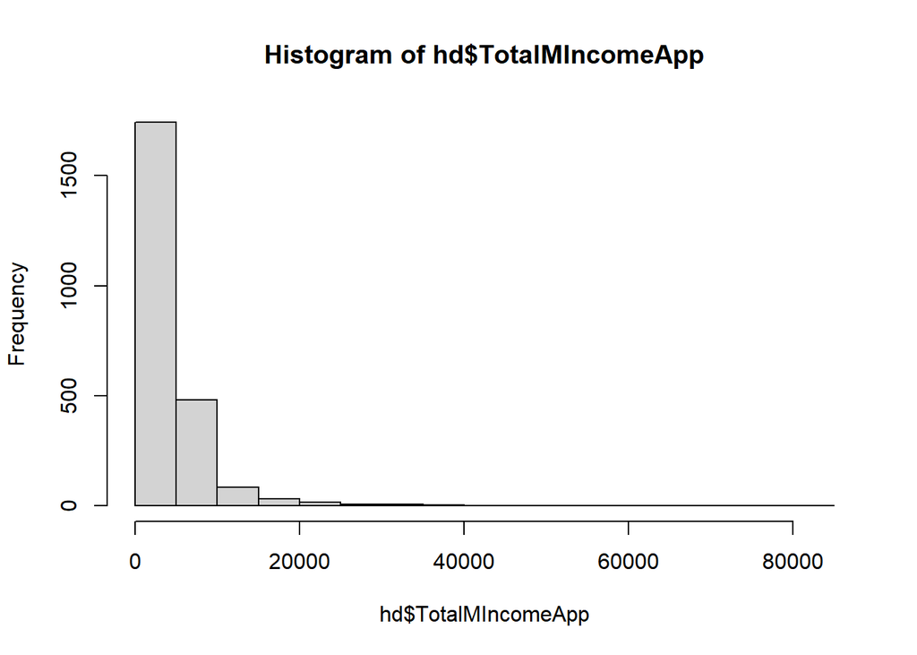

```r
hist(hd$TotalMIncomeApp)
```

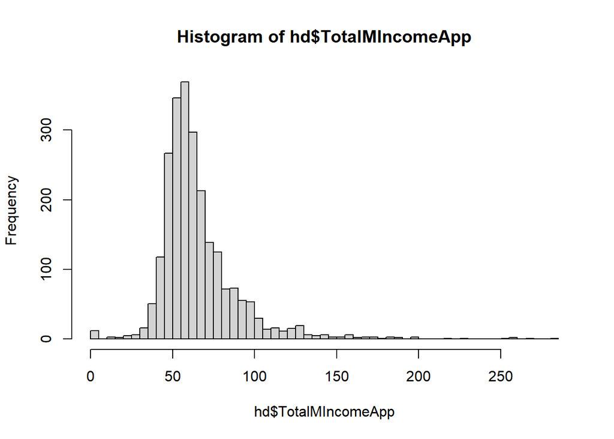

```r
hd$TotalMIncomeApp <- sqrt(hd$TotalMIncomeApp) #skewed
hist(hd$TotalMIncomeApp, breaks = 50)
```

```r
summary(hd$TotalMIncomeApp)
```

```
##    Min. 1st Qu.  Median    Mean 3rd Qu.    Max.
##    0.00   51.87   59.98   65.62   72.91  284.60
```

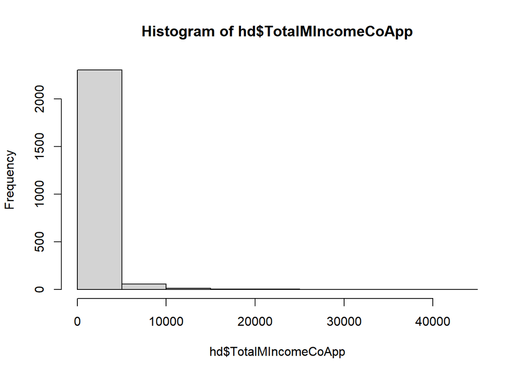

```r
hist(hd$TotalMIncomeCoApp)
```

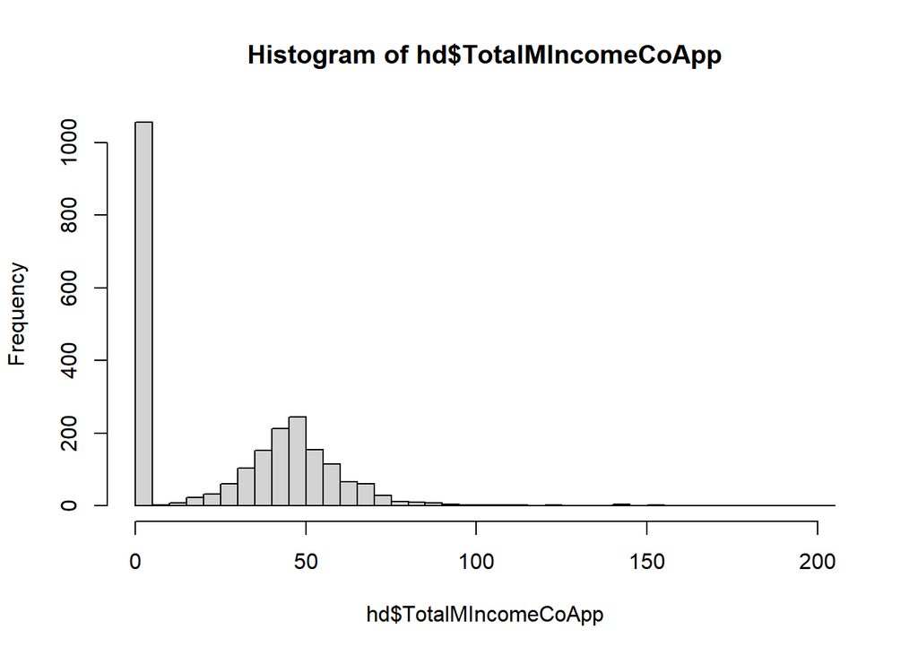

```r
hd$TotalMIncomeCoApp <- sqrt(hd$TotalMIncomeCoApp) #skewed right
hist(hd$TotalMIncomeCoApp, breaks = 50)
```

```r
summary(hd$TotalMIncomeCoApp)
```

```
##    Min. 1st Qu.  Median    Mean 3rd Qu.    Max.
##    0.00    0.00   30.36   26.86   48.01  204.12
```

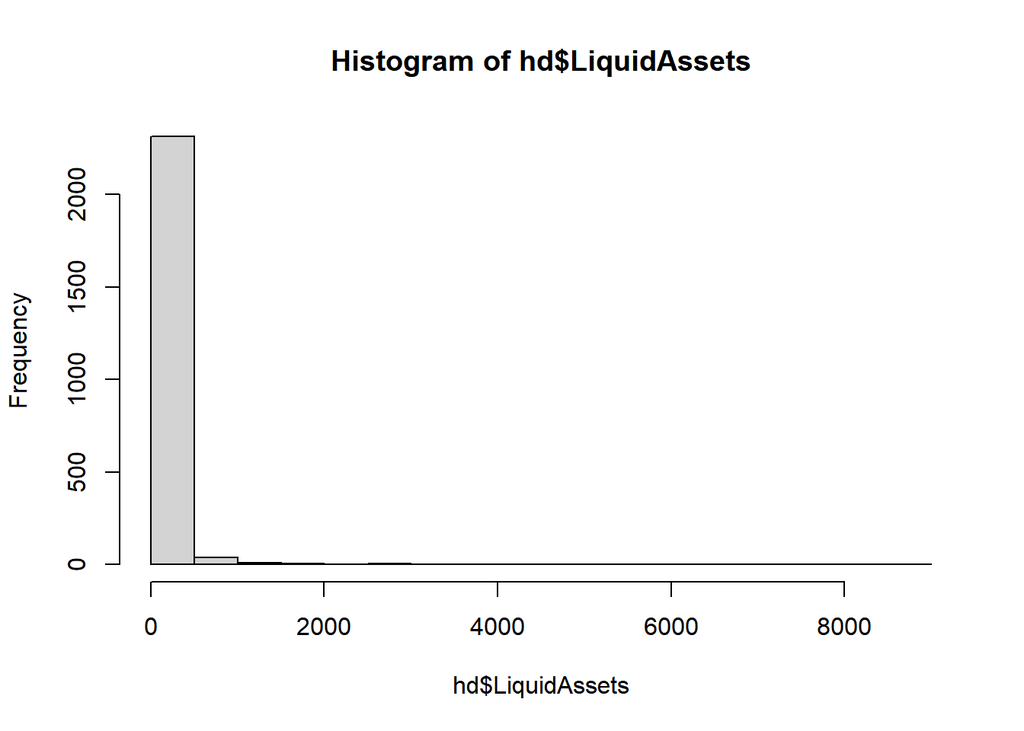

```r
hist(hd$LiquidAssets)
```

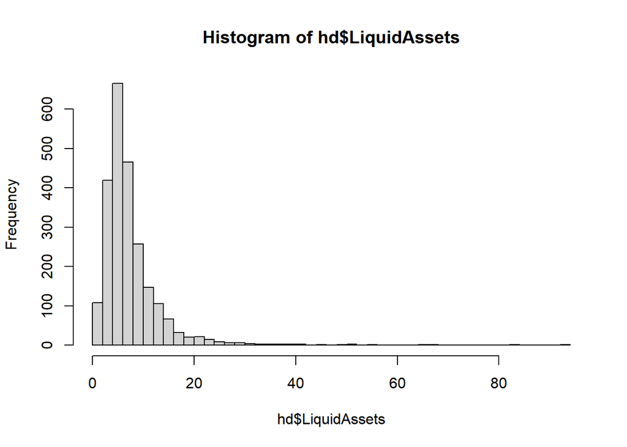

```r
hd$LiquidAssets <- sqrt(hd$LiquidAssets) #skewed right
hist(hd$LiquidAssets, breaks = 50)
```

```r
summary(hd$LiquidAssets)
```

```
##    Min. 1st Qu.  Median    Mean 3rd Qu.    Max.    NA's
##   0.000   4.243   6.000   7.488   8.944  93.005      12
```

## 2.4 Sample Summary

*See the print out for all other summary statistics.

# 3 Part C

## 3.1 Logistic Regression

```r
library(pROC)
library(rpart.plot)
library(rpart.plot)
library(party)
library(randomForest)
library(e1071)
library(jtools)


fit.hd <- glm(TypeAction ~ ., data = hd, family = "binomial", na.action = na.roughfix)

summ(fit.hd)
```

| Observations | 2380 |
| --- | --- |
| Dependent variable | TypeAction |
| Type | Generalized linear model |
| Family | binomial |
| Link | logit |

| χ²(59) | 1073.00 |
| --- | --- |
| Pseudo-R² (Cragg-Uhler) | 0.70 |
| Pseudo-R² (McFadden) | 0.62 |
| AIC | 791.17 |
| BIC | 1137.66 |

|  | Est. | S.E. | z val. | p |
| --- | --- | --- | --- | --- |
| (Intercept) | 17.69 | 3548.82 | 0.00 | 1.00 |
| `Debt/IncomeTotal` | -0.06 | 0.01 | -3.99 | 0.00 |
| RaceApplWhite | 0.34 | 0.39 | 0.87 | 0.38 |
| MaritalStUnmarried (separated, single, divorced, or widowed) | -0.70 | 0.28 | -2.45 | 0.01 |
| SelfEmpAppSelf-employed | -0.57 | 0.31 | -1.83 | 0.07 |
| school | 0.07 | 0.04 | 1.88 | 0.06 |
| LoanAmmount | -0.01 | 0.00 | -2.17 | 0.03 |
| PurchTypeFNMA | 4.33 | 0.99 | 4.37 | 0.00 |
| PurchTypeFHLMC | 18.54 | 634.52 | 0.03 | 0.98 |
| PurchTypeFMHA | 17.69 | 1581.87 | 0.01 | 0.99 |
| PurchTypeCommercial Bank | 16.95 | 1639.34 | 0.01 | 0.99 |
| PurchTypeSavings bank or savings association | 17.71 | 4486.09 | 0.00 | 1.00 |
| PurchTypeLife Insurance company | 18.39 | 835.42 | 0.02 | 0.98 |
| PurchTypeAffiliate instituion | 2.64 | 0.66 | 3.99 | 0.00 |
| PurchasePrice | -0.00 | 0.00 | -0.43 | 0.67 |
| TermLoan | -0.00 | 0.00 | -1.67 | 0.09 |
| F_or_A_loanFixed | -1.43 | 0.25 | -5.81 | 0.00 |
| AppraisedValue | 0.01 | 0.00 | 1.86 | 0.06 |
| PMIsoughtYes | 1.73 | 0.43 | 4.03 | 0.00 |
| PMIdeniedPMI sought and DENIED | -5.81 | 0.78 | -7.45 | 0.00 |
| UnverInfoSome information unverifiable | -3.01 | 0.36 | -8.44 | 0.00 |
| Reviewed | 0.34 | 0.10 | 3.29 | 0.00 |
| dnotownNot owner occupied, or information not available | -0.88 | 0.50 | -1.77 | 0.08 |
| YearsAppLW | 0.11 | 0.13 | 0.90 | 0.37 |
| YearsAppJob | 0.09 | 0.11 | 0.82 | 0.41 |
| netw | -0.00 | 0.00 | -0.25 | 0.80 |
| `Debt/IncomeHousing` | 0.01 | 0.02 | 0.43 | 0.66 |
| AppHistoryGoodYes | 3.34 | 0.35 | 9.62 | 0.00 |
| CH_mortgageNo mortgage payment history | -0.64 | 0.28 | -2.30 | 0.02 |
| CH_mortgageONe or two late mortgage payments | -0.39 | 0.67 | -0.57 | 0.57 |
| CH_mortgageMore than two late mortgage payments | 0.61 | 0.82 | 0.74 | 0.46 |
| CH_consumerOne or two slow pay accounts each with one or two payments 30 days past due | -0.26 | 0.29 | -0.91 | 0.36 |
| CH_consumerMore than two slow pay accounts each with one or two payments 30 days past due; or one or two chronic slow pay accounts with three or more payments 30 days paste due in any 12-month period | -0.01 | 0.49 | -0.03 | 0.98 |
| CH_consumerinsufficient credit history or references for determination | 0.64 | 0.65 | 0.98 | 0.32 |
| CH_consumerdelinquent credit history containing accounts with a history of payments 60 days past due | -0.10 | 0.44 | -0.24 | 0.81 |
| CH_consumerSerious delinquencies containing accounts with a history of payments 90 days past due | 0.01 | 0.38 | 0.02 | 0.98 |
| CH_publicBankruptcy or defaults | -0.29 | 0.35 | -0.84 | 0.40 |
| LiquidAssets | -0.01 | 0.02 | -0.40 | 0.69 |
| TotalMIncomeApp | -0.01 | 0.01 | -1.44 | 0.15 |
| TotalMIncomeCoApp | -0.01 | 0.01 | -1.57 | 0.12 |
| OtherFinancing | -0.00 | 0.00 | -2.29 | 0.02 |
| GrantDPYes | 0.14 | 0.30 | 0.46 | 0.65 |
| CoSignYes | 0.67 | 0.72 | 0.93 | 0.35 |
| uria | 0.01 | 0.05 | 0.15 | 0.88 |
| RaceCoAppAsian or Pacific Islander | -15.60 | 3548.82 | -0.00 | 1.00 |
| RaceCoAppBlack | -15.08 | 3548.82 | -0.00 | 1.00 |
| RaceCoAppHispanic | 0.46 | 5476.92 | 0.00 | 1.00 |
| RaceCoAppWhite | -15.00 | 3548.82 | -0.00 | 1.00 |
| RaceCoAppOther | -13.80 | 3548.82 | -0.00 | 1.00 |
| RaceCoAppNot Applicable | -15.55 | 3548.82 | -0.00 | 1.00 |
| SexAppFemale | 0.61 | 0.31 | 1.98 | 0.05 |
| SexCoAppFemale | 0.58 | 0.44 | 1.32 | 0.19 |
| DepApp | 0.01 | 0.11 | 0.05 | 0.96 |
| old> MSA median | -0.81 | 0.26 | -3.12 | 0.00 |
| CountyLocother | 0.36 | 0.36 | 0.99 | 0.32 |
| rtdum> .30 | -0.58 | 0.52 | -1.12 | 0.26 |
| bd> MSA median | 0.22 | 0.23 | 0.99 | 0.32 |
| mi> MSA median | -0.31 | 0.35 | -0.90 | 0.37 |
| vr> MSA median | -0.30 | 0.23 | -1.29 | 0.20 |
| chvalc | -0.00 | 0.00 | -2.18 | 0.03 |

Standard errors: MLE

### 3.1.1 Interpretation of Hypotheses:

Hypothesis 1 was supported: Debt/Income Total was negatively related to the likelihood of being approved (b = -.06, SE = .01, p < .05).

Hypothesis 2 was supported: Not being married was negatively related to the likelihood of being approved (b = -.7, SE =.28, p < .05).

Hypothesis 3 was not supported: Being self-employed was not significantly related to the likelihood of being approved (b = -.57, SE = .31, p = .07)

Hypothesis 4 was not supported: Years of education was not significantly related to the likelihood of being approved, although it is nearing significance (b = .07, SE = .04, p = .06)

Hypothesis 5 was not supported: Race was not significantly related to the likelihood of being approved (White -> b = .34, SE = .39, p = .38)

## 3.2 Model Estimation

```r
prob.dh <-predict(fit.hd, hd, type = "response", na.action = na.roughfix)

logit.pred <- factor(prob.dh > .50, levels = c(FALSE, TRUE),labels = c("Loan Denied", "Loan Approved")) #why would I get NA's here and how can I get rid of them?

logit.perf <-  table(hd$TypeAction, logit.pred, dnn = c("Actual", "Predicted"))

logit.perf
```

```
##                Predicted
## Actual          Loan Denied Loan Approved
##   Loan Denied           196            89
##   Loan Approved          39          2056
```

## 3.3 ROC Curve and AUC

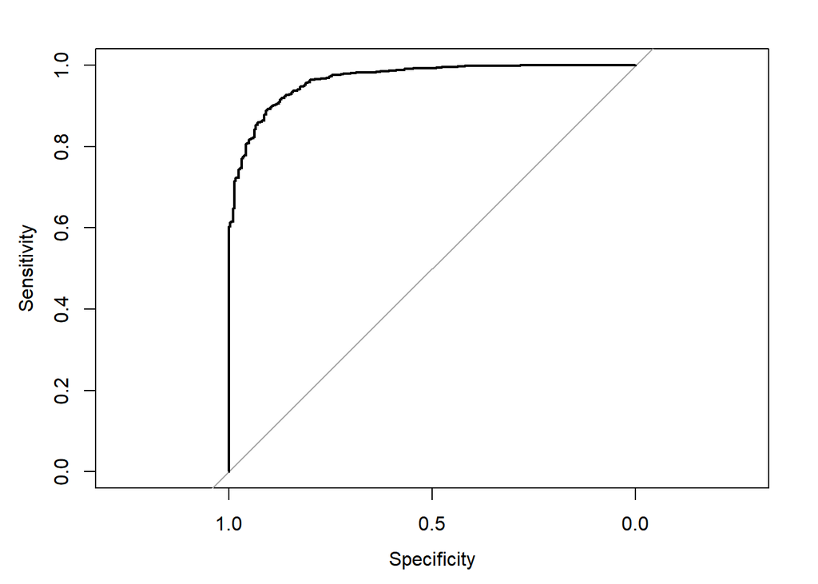

```r
my_roc <- roc(hd$TypeAction ~ prob.dh, plot = TRUE)
```

```r
auc(my_roc)
```

```
## Area under the curve: 0.9655
```

## 3.4 Confusion Matrix with Alternative Cut offs

```r
# Finds Optimal threshold
coords(my_roc, "best", ret = "threshold")
```

```
##   threshold
## 1 0.8979749
```

```r
threshold <- my_roc$thresholds[which.max(my_roc$sensitivities + my_roc$specificities)]

threshold
```

```
## [1] 0.8979749
```

```r
logit.pred.thresh <- factor(prob.dh > threshold, levels = c(FALSE, TRUE),labels = c("Loan Denied", "Loan Approved")) #why would I get NA's here and how can I get rid of them?

logit.perf.thresh <-  table(hd$TypeAction, logit.pred.thresh, dnn = c("Actual", "Predicted"))
logit.perf.thresh
```

```
##                Predicted
## Actual          Loan Denied Loan Approved
##   Loan Denied           259            26
##   Loan Approved         231          1864
```

```r
logit.pred70<- factor(prob.dh > .70, levels = c(FALSE, TRUE),labels = c("Loan Denied", "Loan Approved")) #why would I get NA's here and how can I get rid of them?

logit.perf70 <-  table(hd$TypeAction, logit.pred70, dnn = c("Actual", "Predicted"))
logit.perf70
```

```
##                Predicted
## Actual          Loan Denied Loan Approved
##   Loan Denied           223            62
##   Loan Approved          73          2022
```

### 3.4.2 .65 Cut Off

```r
logit.pred65<- factor(prob.dh > .65, levels = c(FALSE, TRUE),labels = c("Loan Denied", "Loan Approved")) #why would I get NA's here and how can I get rid of them?

logit.perf65 <-  table(hd$TypeAction, logit.pred65, dnn = c("Actual", "Predicted"))
logit.perf65
```

```
##                Predicted
## Actual          Loan Denied Loan Approved
##   Loan Denied           215            70
##   Loan Approved          59          2036
```

### 3.4.3 .85 Cut Off

```r
logit.pred85<- factor(prob.dh > .85, levels = c(FALSE, TRUE),labels = c("Loan Denied", "Loan Approved")) #why would I get NA's here and how can I get rid of them?

logit.perf85 <-  table(hd$TypeAction, logit.pred85, dnn = c("Actual", "Predicted"))
logit.perf85
```

```
##                Predicted
## Actual          Loan Denied Loan Approved
##   Loan Denied           245            40
##   Loan Approved         156          1939
```

### 3.4.4 .80 Cut Off

```r
logit.pred80<- factor(prob.dh > .80, levels = c(FALSE, TRUE),labels = c("Loan Denied", "Loan Approved")) #why would I get NA's here and how can I get rid of them?

logit.perf80 <-  table(hd$TypeAction, logit.pred80, dnn = c("Actual", "Predicted"))
logit.perf80
```

```
##                Predicted
## Actual          Loan Denied Loan Approved
##   Loan Denied           235            50
##   Loan Approved         120          1975
```

### 3.4.5 .05 Cut Off

```r
logit.pred05<- factor(prob.dh > .05, levels = c(FALSE, TRUE),labels = c("Loan Denied", "Loan Approved")) #why would I get NA's here and how can I get rid of them?

logit.perf05 <-  table(hd$TypeAction, logit.pred05, dnn = c("Actual", "Predicted"))
logit.perf05
```

```
##                Predicted
## Actual          Loan Denied Loan Approved
##   Loan Denied            77           208
##   Loan Approved           1          2094
```

### 3.4.6 .60 Cut Off

```r
logit.pred60<- factor(prob.dh > .60, levels = c(FALSE, TRUE),labels = c("Loan Denied", "Loan Approved")) #why would I get NA's here and how can I get rid of them?

logit.perf60 <-  table(hd$TypeAction, logit.pred60, dnn = c("Actual", "Predicted"))
logit.perf60
```

```
##                Predicted
## Actual          Loan Denied Loan Approved
##   Loan Denied           209            76
##   Loan Approved          50          2045
```

### 3.4.7 .55 Cut Off

```r
logit.pred55<- factor(prob.dh > .55, levels = c(FALSE, TRUE),labels = c("Loan Denied", "Loan Approved")) #why would I get NA's here and how can I get rid of them?

logit.perf55 <-  table(hd$TypeAction, logit.pred55, dnn = c("Actual", "Predicted"))
logit.perf55
```

```
##                Predicted
## Actual          Loan Denied Loan Approved
##   Loan Denied           205            80
##   Loan Approved          45          2050
```

### 3.4.8 .30 Cut Off

```r
logit.pred30<- factor(prob.dh > .30, levels = c(FALSE, TRUE),labels = c("Loan Denied", "Loan Approved")) #why would I get NA's here and how can I get rid of them?

logit.perf30 <-  table(hd$TypeAction, logit.pred30, dnn = c("Actual", "Predicted"))
logit.perf30
```

```
##                Predicted
## Actual          Loan Denied Loan Approved
##   Loan Denied           162           123
##   Loan Approved          24          2071
```

### 3.4.9 .25 Cut Off

```r
logit.pred25<- factor(prob.dh > .25, levels = c(FALSE, TRUE),labels = c("Loan Denied", "Loan Approved")) #why would I get NA's here and how can I get rid of them?

logit.perf25 <-  table(hd$TypeAction, logit.pred25, dnn = c("Actual", "Predicted"))
logit.perf25
```

```
##                Predicted
## Actual          Loan Denied Loan Approved
##   Loan Denied           159           126
##   Loan Approved          20          2075
```

## 3.5 Model Evaluation

```r
#performance function

performance <- function(table, n = 4){
  if(!all(dim(table) == c(2,2)))
    stop("Must be a 2 x 2 table")
  tn = table[1,1]
  fp = table[1,2]
  fn = table[2,1]
  tp = table[2,2]
  sensitivity = tp/(tp+fn)
  specificity = tn/(tn+fp)
  ppp = tp/(tp+fp)
  npp = tn/(tn+fp)
  hitrate = (tp+tn)/(tp+tn+fp+fn)
  result <- paste0("Sensitivity = ", round(sensitivity,n),
                   "\nSpecificity = ",round(specificity,n),
                   "\nPositive Predictive Value = ", round(ppp,n),
                   "\nNegative Predictive Value = ", round(npp,n),
                   "\nAccuracy = ", round(hitrate,n))
  cat(result)
}

performance(logit.perf05) # 0.05
```

```
## Sensitivity = 0.9995
## Specificity = 0.2702
## Positive Predictive Value = 0.9096
## Negative Predictive Value = 0.2702
## Accuracy = 0.9122
```

```r
performance(logit.perf25) # 0.25
```

```
## Sensitivity = 0.9905
## Specificity = 0.5579
## Positive Predictive Value = 0.9428
## Negative Predictive Value = 0.5579
## Accuracy = 0.9387
```

```r
performance(logit.perf30) # 0.30
```

```
## Sensitivity = 0.9885
## Specificity = 0.5684
## Positive Predictive Value = 0.9439
## Negative Predictive Value = 0.5684
## Accuracy = 0.9382
```

```r
performance(logit.perf) # 0.50
```

```
## Sensitivity = 0.9814
## Specificity = 0.6877
## Positive Predictive Value = 0.9585
## Negative Predictive Value = 0.6877
## Accuracy = 0.9462
```

```r
performance(logit.perf55) # 0.55**
```

```
## Sensitivity = 0.9785
## Specificity = 0.7193
## Positive Predictive Value = 0.9624
## Negative Predictive Value = 0.7193
## Accuracy = 0.9475
```

```r
performance(logit.perf60) # 0.60
```

```
## Sensitivity = 0.9761
## Specificity = 0.7333
## Positive Predictive Value = 0.9642
## Negative Predictive Value = 0.7333
## Accuracy = 0.9471
```

```r
performance(logit.perf65) # 0.65
```

```
## Sensitivity = 0.9718
## Specificity = 0.7544
## Positive Predictive Value = 0.9668
## Negative Predictive Value = 0.7544
## Accuracy = 0.9458
```

```r
performance(logit.perf70) # 0.70
```

```
## Sensitivity = 0.9652
## Specificity = 0.7825
## Positive Predictive Value = 0.9702
## Negative Predictive Value = 0.7825
## Accuracy = 0.9433
```

```r
performance(logit.perf80) # 0.80
```

```
## Sensitivity = 0.9427
## Specificity = 0.8246
## Positive Predictive Value = 0.9753
## Negative Predictive Value = 0.8246
## Accuracy = 0.9286
```

```r
performance(logit.perf85) # 0.85
```

```
## Sensitivity = 0.9255
## Specificity = 0.8596
## Positive Predictive Value = 0.9798
## Negative Predictive Value = 0.8596
## Accuracy = 0.9176
```

```r
performance(logit.perf.thresh) # 0.8979749
```

```
## Sensitivity = 0.8897
## Specificity = 0.9088
## Positive Predictive Value = 0.9862
## Negative Predictive Value = 0.9088
## Accuracy = 0.892
```

## 3.6 Summary of Findings

After performing several logistic regressions, each with different cutoff points, the model with a cutoff of .898 (logit.perf.thresh) yielded the highest collective sensitivity (.8897) and specificity (.9088) scores (as it was the optimal cut off score) whereas the model with a cutoff of .55 (logit.perf55) yielded the highest accuracy score (.9475). As we are most concerned with accuracy, we will use a cutoff of .55 going forward.

# 4 Part D

## 4.1 10 Fold Cross Validation

```r
# do a cross
#install.packages("boot")


library(boot)


set.seed(1234)

train <- sample(nrow(hd), 0.7*nrow(hd))
hd.train <-  hd[train,]
hd.validate <- hd[-train,]

hd.train <- (na.roughfix(hd.train))
hd.validate <- (na.roughfix(hd.validate)) #replaces with mean or median depending on data type


table(hd.train$TypeAction)
```

```
##
##   Loan Denied Loan Approved
##           200          1466
```

```r
table(hd.validate$TypeAction)
```

```
##
##   Loan Denied Loan Approved
##            85           629
```

```r
#cv.glm(hd.train, fit.hd, K = 10) #error with RaceCoApp column 33

train.fit <- cv.glm(data = hd.train[,-33], glmfit =  fit.hd, K = 10)
```

## 4.2 Model Estimates

```r
prediction <- predict(fit.hd, hd.validate, type = "response", select =train.fit$delta[2], na.action = na.roughfix)

cv.pred50 <- factor(prediction > .50, levels = c(FALSE, TRUE),labels = c("Loan Denied", "Loan Approved"))

cv.perf50 <-  table(hd.validate$TypeAction, cv.pred50, dnn = c("Actual", "Predicted"))

cv.perf50
```

```
##                Predicted
## Actual          Loan Denied Loan Approved
##   Loan Denied            54            31
##   Loan Approved          12           617
```

### 4.2.1 ROC, AUC, Threshold Cutoff (.946)

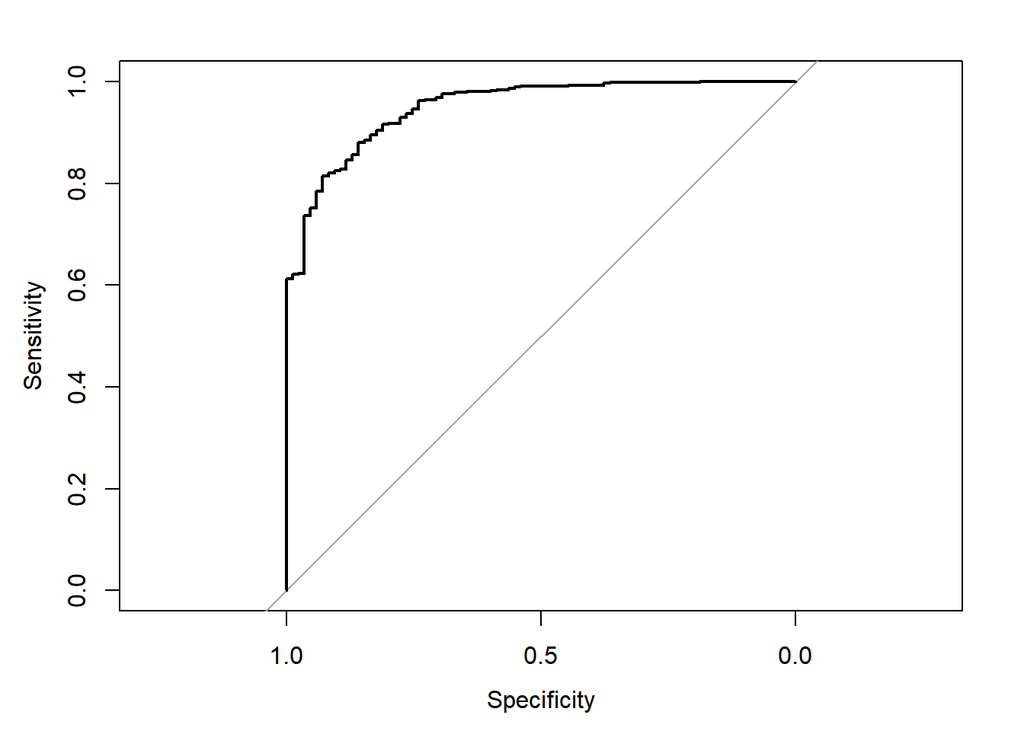

```r
my_roc.cv <- roc(hd.validate$TypeAction ~ prediction, plot = TRUE)
```

```r
auc(my_roc.cv)
```

```
## Area under the curve: 0.9496
```

```r
coords(my_roc.cv, "best", ret = "threshold")
```

```
##   threshold
## 1 0.9464234
```

```r
threshold.cv <- my_roc.cv$thresholds[which.max(my_roc.cv$sensitivities + my_roc.cv$specificities)]

threshold.cv
```

```
## [1] 0.9464234
```

```r
cv.pred.thresh <- factor(prediction > threshold.cv, levels = c(FALSE, TRUE),labels = c("Loan Denied", "Loan Approved"))

cv.perf.thresh <-  table(hd.validate$TypeAction, cv.pred.thresh, dnn = c("Actual", "Predicted"))
cv.perf.thresh
```

```
##                Predicted
## Actual          Loan Denied Loan Approved
##   Loan Denied            79             6
##   Loan Approved         117           512
```

### 4.2.2 .10 Cut Off

```r
cv.pred10 <- factor(prediction > .10, levels = c(FALSE, TRUE),labels = c("Loan Denied", "Loan Approved"))

cv.perf10 <-  table(hd.validate$TypeAction, cv.pred10, dnn = c("Actual", "Predicted"))
cv.perf10
```

```
##                Predicted
## Actual          Loan Denied Loan Approved
##   Loan Denied            29            56
##   Loan Approved           1           628
```

### 4.2.3 .25 Cut Off

```r
cv.pred25 <- factor(prediction > .25, levels = c(FALSE, TRUE),labels = c("Loan Denied", "Loan Approved"))

cv.perf25 <-  table(hd.validate$TypeAction, cv.pred25, dnn = c("Actual", "Predicted"))
cv.perf25
```

```
##                Predicted
## Actual          Loan Denied Loan Approved
##   Loan Denied            46            39
##   Loan Approved           7           622
```

### 4.2.4 .40 Cut Off

```r
cv.pred40 <- factor(prediction > .40, levels = c(FALSE, TRUE),labels = c("Loan Denied", "Loan Approved"))

cv.perf40 <-  table(hd.validate$TypeAction, cv.pred40, dnn = c("Actual", "Predicted"))
cv.perf40
```

```
##                Predicted
## Actual          Loan Denied Loan Approved
##   Loan Denied            50            35
##   Loan Approved          11           618
```

```r
cv.pred55 <- factor(prediction > .55, levels = c(FALSE, TRUE),labels = c("Loan Denied", "Loan Approved"))

cv.perf55 <-  table(hd.validate$TypeAction, cv.pred55, dnn = c("Actual", "Predicted"))
cv.perf55
```

```
##                Predicted
## Actual          Loan Denied Loan Approved
##   Loan Denied            56            29
##   Loan Approved          13           616
```

### 4.2.6 .60 Cut Off

```r
cv.pred60 <- factor(prediction > .60, levels = c(FALSE, TRUE),labels = c("Loan Denied", "Loan Approved"))

cv.perf60 <-  table(hd.validate$TypeAction, cv.pred60, dnn = c("Actual", "Predicted"))
cv.perf60
```

```
##                Predicted
## Actual          Loan Denied Loan Approved
##   Loan Denied            59            26
##   Loan Approved          15           614
```

### 4.2.7 .65 Cut Off

```r
cv.pred65 <- factor(prediction > .65, levels = c(FALSE, TRUE),labels = c("Loan Denied", "Loan Approved"))

cv.perf65 <-  table(hd.validate$TypeAction, cv.pred65, dnn = c("Actual", "Predicted"))
cv.perf65
```

```
##                Predicted
## Actual          Loan Denied Loan Approved
##   Loan Denied            59            26
##   Loan Approved          17           612
```

### 4.2.8 .75 Cut Off

```r
cv.pred75 <- factor(prediction > .75, levels = c(FALSE, TRUE),labels = c("Loan Denied", "Loan Approved"))

cv.perf75 <-  table(hd.validate$TypeAction, cv.pred75, dnn = c("Actual", "Predicted"))
cv.perf75
```

```
##                Predicted
## Actual          Loan Denied Loan Approved
##   Loan Denied            63            22
##   Loan Approved          30           599
```

### 4.2.9 Performance Tables

```r
performance(cv.perf10)
```

```
## Sensitivity = 0.9984
## Specificity = 0.3412
## Positive Predictive Value = 0.9181
## Negative Predictive Value = 0.3412
## Accuracy = 0.9202
```

```r
performance(cv.perf25)
```

```
## Sensitivity = 0.9889
## Specificity = 0.5412
## Positive Predictive Value = 0.941
## Negative Predictive Value = 0.5412
## Accuracy = 0.9356
```

```r
performance(cv.perf40)
```

```
## Sensitivity = 0.9825
## Specificity = 0.5882
## Positive Predictive Value = 0.9464
## Negative Predictive Value = 0.5882
## Accuracy = 0.9356
```

```r
performance(cv.perf50)
```

```
## Sensitivity = 0.9809
## Specificity = 0.6353
## Positive Predictive Value = 0.9522
## Negative Predictive Value = 0.6353
## Accuracy = 0.9398
```

```r
performance(cv.perf55)
```

```
## Sensitivity = 0.9793
## Specificity = 0.6588
## Positive Predictive Value = 0.955
## Negative Predictive Value = 0.6588
## Accuracy = 0.9412
```

```r
performance(cv.perf60) #***
```

```
## Sensitivity = 0.9762
## Specificity = 0.6941
## Positive Predictive Value = 0.9594
## Negative Predictive Value = 0.6941
## Accuracy = 0.9426
```

```r
performance(cv.perf65)
```

```
## Sensitivity = 0.973
## Specificity = 0.6941
## Positive Predictive Value = 0.9592
## Negative Predictive Value = 0.6941
## Accuracy = 0.9398
```

```r
performance(cv.perf75)
```

```
## Sensitivity = 0.9523
## Specificity = 0.7412
## Positive Predictive Value = 0.9646
## Negative Predictive Value = 0.7412
## Accuracy = 0.9272
```

```r
performance(cv.perf.thresh) # 0.946
```

```
## Sensitivity = 0.814
## Specificity = 0.9294
## Positive Predictive Value = 0.9884
## Negative Predictive Value = 0.9294
## Accuracy = 0.8277
```

# 5 Part E

## 5.1 Superior Model Classification

After conducting the logistic cross-validation, the optimum cut off value of .946 was found, which yielded the highest collective sensitivity (.814) and specificity (.9294) scores. However, a cutoff of .60 yielded the highest model accuracy score (.9426). Therefore, we will be using the cutoff value of .60 as we are concerned the most with accuracy.

## 5.2 Re-estimating with full data sample

```r
pre <- predict(fit.hd, hd, type = "response", select =train.fit$delta[2], na.action = na.roughfix)

xcv.pred60 <- factor(pre > .60, levels = c(FALSE, TRUE),labels = c("Loan Denied", "Loan Approved"))

xcv.perf60 <-  table(hd$TypeAction, xcv.pred60, dnn = c("Actual", "Predicted"))

xcv.perf60
```

```
##                Predicted
## Actual          Loan Denied Loan Approved
##   Loan Denied           209            76
##   Loan Approved          50          2045
```

### 5.2.1 ROC and AUC

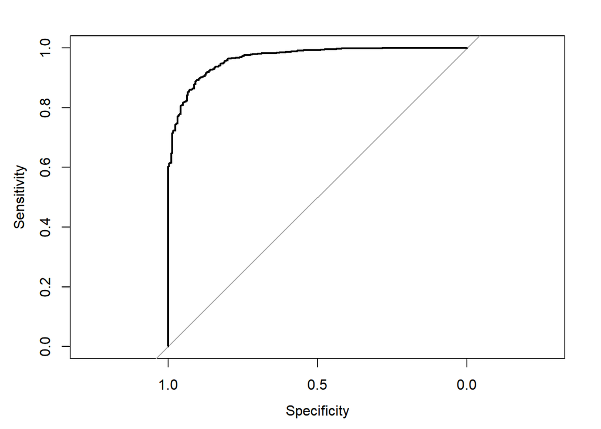

```r
my_roc.cvx <- roc(hd$TypeAction ~ pre, plot = TRUE)
```

```r
auc(my_roc.cvx)
```

```
## Area under the curve: 0.9655
```

### 5.2.2 Confusion Matrix

```r
xcv.perf60
```

```
##                Predicted
## Actual          Loan Denied Loan Approved
##   Loan Denied           209            76
##   Loan Approved          50          2045
```

### 5.2.3 Model Evaluation

```r
performance(xcv.perf60)
```

```
## Sensitivity = 0.9761
## Specificity = 0.7333
## Positive Predictive Value = 0.9642
## Negative Predictive Value = 0.7333
## Accuracy = 0.9471
```

```r
performance(logit.perf60)
```

```
## Sensitivity = 0.9761
## Specificity = 0.7333
## Positive Predictive Value = 0.9642
## Negative Predictive Value = 0.7333
## Accuracy = 0.9471
```

```r
xcv.perf60
```

```
##                Predicted
## Actual          Loan Denied Loan Approved
##   Loan Denied           209            76
##   Loan Approved          50          2045
```

```r
logit.perf60
```

```
##                Predicted
## Actual          Loan Denied Loan Approved
##   Loan Denied           209            76
##   Loan Approved          50          2045
```

```r
auc(my_roc.cvx)
```

```
## Area under the curve: 0.9655
```

```r
auc(my_roc)
```

```
## Area under the curve: 0.9655
```

## 5.3 Summary

After evaluating the performance of the superior model and the model estimated in part C, there were no differences between the two models on any criteria. Additionally, the AUC for the ROC curve was equal for both models. Being honest, I’m not quite sure why this is the case, as I did add in the delta values from the cross validation. Perhaps they were so insignificant that they did not have an effect on the model. Or, perhaps I made a mistake. Either way, I have learned a lot and enjoyed the course - Thanks Josh!